# Object Models in R

Di Cook, Heike Hofmann  
4/4/2014

### Ouline

- Object oriented programming in R: methods and classes
- S3 versus S4 classes in R
- Example for S4 class

### Object-Oriented Programming (OOP)

- Technically R is not OOP, but it does allow function and class-based programming
- Classes and associated Methods:
  - A **class** is a description of a thing
  - A **method** is an implementation of a generic function for an object of a particular class

```r
class(pi)
```

```
[1] "numeric"
```

```r
class("hello")
```

```
[1] "character"
```

```r
class(lm(rnorm(100)~rnorm(100)))
```

```
[1] "lm"
```

### Methods

Methods allow us to adjust actions to different objects, e.g.:

```r
print('hello')
```

```
[1] "hello"
```

```r
x <- rnorm(100); y <- rnorm(100)
print(lm(y~x))
```

```
Call:
lm(formula = y ~ x)

Coefficients:
(Intercept)            x
    -0.1358      -0.0504
```

The same function call (`print`) triggers different responses - in fact, the call goes to the default `print.default` method in the first case and `print.lm` for the second case.

### Methods

Which methods exist?

```r
head(methods("print"))
```

```
[1] "print.acf"     "print.AES"     "print.anova"   "print.aov"
[5] "print.aovlist" "print.ar"
```

```r
tail(methods("print"))
```

```
[1] "print.undoc"     "print.vignette"  "print.warnings"  "print.xgettext"
[5] "print.xngettext" "print.xtabs"
```

```r
length(methods("print"))
```

```
[1] 179
```

### Methods

```r
print.lm
```

```
function (x, digits = max(3L, getOption("digits") - 3L), ...)
{
    cat("\nCall:\n", paste(deparse(x$call), sep = "\n", collapse = "\n"),
        "\n\n", sep = "")
    if (length(coef(x))) {
        cat("Coefficients:\n")
        print.default(format(coef(x), digits = digits), print.gap = 2L,
            quote = FALSE)
    }
    else cat("No coefficients\n")
    cat("\n")
    invisible(x)
}
<bytecode: 0x103285270>
<environment: namespace:stats>
```

```r
print(lm(y~x))
```

```
Call:
lm(formula = y ~ x)

Coefficients:
(Intercept)            x
    -0.1358      -0.0504
```

### Writing Methods

```r
setMethod("print", "character", function(x = "character") {
  paste(x,"is a character")
})
```

```
[1] "print"
```

```r
print("hello")
```

```
[1] "hello is a character"
```

```r
print(LETTERS[1:3])
```

```
[1] "A is a character" "B is a character" "C is a character"
```

```r
LETTERS[1:3]
```

```
[1] "A" "B" "C"
```

### Getting rid of the methods that I called ...

Having the 'is a character' announcement after every string is a bit weird, so we do not want to keep this particular functionality:

```r
removeMethod("print", "character")
```

```
[1] TRUE
```

```r
print("hello")
```

```
[1] "hello"
```

### S3 versus S4 objects

- S3 is the old style of R objects
- S3 should - according to R style and package guidelines - no longer be used for new packages
- Google’s R style guide suggests ignoring S4 unless bindings to C++ are needed.
- generic functions can have both S3 and S4 methods
- S3 and S4 are conceptually the same but implemented very differently.
- S4 is more formal and rigorous. S3 more interactive and flexible. S3 objects is defined by stating its class: `class(x) <- "new_S3_class"`
- `setMethod` implements an S4 method, `showMethods` only shows S4 methods.
- telling the difference between S3 and S4:

```r
methods("princomp") # if any, list of all S3 methods
```

```
[1] princomp.default* princomp.formula*

   Non-visible functions are asterisked
```

```r
showMethods("princomp") # if any, list of all S4 methods
```

```
Function "princomp":
 <not an S4 generic function>
```

### S4 objects

- S4 requires that classes and methods are registered, ensuring that the object has all the required components
- Stricter system, avoiding potential ambiguity of S3 classes
- Slots, @: are the elements of the object
- See `methods` package (not to be confused with methods function, which is S3)

### Defining an S4 class

- important step in structuring your code:
  - what are the key parts of your object?
  - how are you envisioning using the new object?
- there is usually a multitude of possibilities of how to organize a class - those decisions will have effects downstream in how efficiently/elegantly the remaining code can be written
- technically: call `setClass(classname, representation(x="numeric", y="character", z="some other class"))`

### Example of S4 objects

On Kaggle: data for digit recognizer challenge (https://www.kaggle.com/c/digit-recognizer)

format of data is atrocious: rows of variables `label`, `pixel0`, `pixel1`, …, `pixel783`

to describe a 28 x 28 grey-scale image and its associated label

let's define a class 'kaggle' for that

```r
setClass("kaggle", representation(label="integer", data="matrix"))
```

Now read some of the data:

```r
digits <- read.csv("http://dicook.github.io/stat585/data/train-digits.csv", nrows=15)
```

Converting a row to a kaggle object:

```r
k1 <- new("kaggle", label=digits[4,1],
    data=matrix(unlist(digits[4,-1]), nrow=28, byrow=TRUE))
```

Now we need a print method:

```r
setMethod("print", "kaggle", function(x) {
  sprintf("label: %d", x@label)
  for (i in 1:28) {
    for (j in 1:28) {
      if (x@data[i,j] == 0) cat(" ")
      else if (x@data[i,j] < 128) cat(".")
      else cat("*")
    }
    cat("\n")
  }
})
```

```
[1] "print"
```

[output not shown]

[output not shown]

and a plotting routine …

```r
setMethod("image", "kaggle", function(x, ...) {
  require(RColorBrewer)
  image(t(x@data[28:1, 1:28]), col=brewer.pal(9, "Greys"))
})
```

```
[1] "image"
```

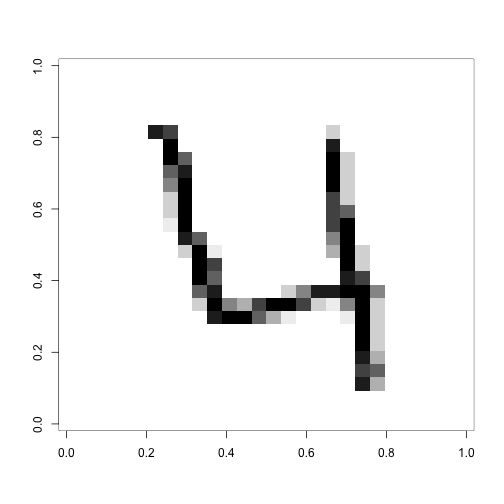

```r
image(k1)
```

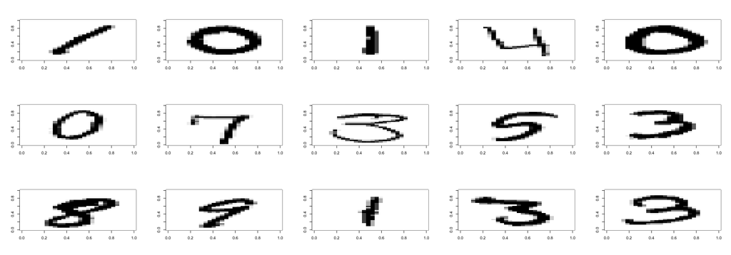

```r
ks <- sapply(1:nrow(digits), function(x) {
  new("kaggle", label=digits[x,1],
    data=matrix(unlist(digits[x,-1]), nrow=28, byrow=TRUE))
  })

par(mfrow=c(3,5))
lapply(ks, image)
```

Now we could define method(s) that help us process the image information - e.g. proportion of pixels that are non-zero, centers of information in x and y direction, number of empty rows/columns, …